# Testing R Markdown Formats

DS-SL

2023-01-29

# 1 Test File of R Markdown

## 1.1 R Notebook

This is an [R Markdown](http://rmarkdown.rstudio.com) file ‘test-rmarkdown.Rmd’ with various output formats, created using ‘RNotebook_Template.Rmd’. When you execute or run a code within the notebook, the results appear beneath the code.

## 1.2 Test Code Chunk (1)

```r
head(cars)
```

|  | speed | dist |
| --- | --- | --- |
| 1 | 4 | 2 |
| 2 | 4 | 10 |
| 3 | 7 | 4 |
| 4 | 7 | 22 |
| 5 | 8 | 16 |
| 6 | 9 | 10 |

## 1.4 Test Code Chunk (3)

```r
knitr::kable(iris[1:6, ])
```

| Sepal.Length | Sepal.Width | Petal.Length | Petal.Width | Species |
| --- | --- | --- | --- | --- |
| 5.1 | 3.5 | 1.4 | 0.2 | setosa |
| 4.9 | 3.0 | 1.4 | 0.2 | setosa |
| 4.7 | 3.2 | 1.3 | 0.2 | setosa |
| 4.6 | 3.1 | 1.5 | 0.2 | setosa |
| 5.0 | 3.6 | 1.4 | 0.2 | setosa |
| 5.4 | 3.9 | 1.7 | 0.4 | setosa |

## 1.5 Test Code Chunk (4)

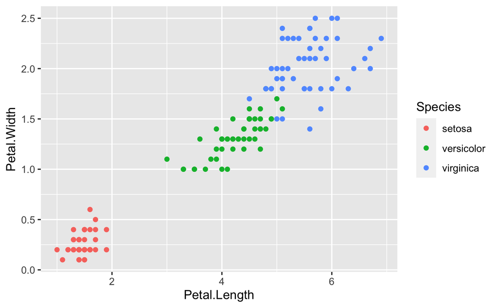

```r
ggplot(iris, aes(x = Petal.Length, y = Petal.Width, col = Species)) +
  geom_point()
```

## 1.6 YAML for Various Output Formats

```
output:
  html_notebook:
    number_sections: yes
  html_document:
    df_print: paged
    number_sections: yes
  word_document:
    number_sections: yes
  pdf_document:
    number_sections: yes
  powerpoint_presentation: default
  ioslides_presentation:
    widescreen: yes
    smaller: yes
  slidy_presentation: default
  beamer_presentation: default
```

# 2 Note

## 2.1 Comments on Presentation Formats

- For slides, a new slide starts at ##, the second-level heading.
- `---` is page break for presentation formats.
- For Word and Powerpoint, you can add your template. See the documents in References

## 2.2 References

- Posit Primers: [Report Reproducibly](https://rmarkdown.rstudio.com/lesson-1.html?_ga=2.60708591.317621277.1671142614-2004472742.1671142614)
- Markdown Quick Reference: Top Menu Bar > Help > Markdown Quick Reference
- Cheat Sheet (Top Menu Bar: Help > Cheat Sheets): RMarkdown Cheat Sheet, RMarkdown Reference Guide
- Books:
  - [R Markdown: The Definitive Guide](https://bookdown.org/yihui/rmarkdown/)
  - [R Markdown Cookbook](https://bookdown.org/yihui/rmarkdown-cookbook/)
- Post error messages to a web search engine.

### 2.2.1 Word or PowerPoint with Style File

- First choose `Knit to word_document` or `Knit to PowerPoint` under Knit to create a Word or PowerPoint Documents as an output.
- Change the style of the output file, and save it as `ref_doc.docx` or `ref_ppt.pptx` accordingly. Confirm that the style file is in the same directory as the Rmd file.
- Change the YAML on top, and add as follows.

```
---
output:
  word_document:
    number_sections: yes
    reference_docx: "ref_doc.docx"
  powerpoint_presentation:
    reference_pptx: "ref_ppt.pptx"
---
```

### 2.2.2 Creating a PDF

If you need to edit the Rmd file created RNotebook, using Save as under File and create a new file, and edit appropriately.

1. Use `Knit to pdf_document` under Knit
2. Use `Knit to word_document` and create a PDF from Word after editing the Word file if necessary.
3. Run all code chunks, and Preview Notebook. Then open it in a web browser such as Google Chrome, Edge or Safari and use print to pdf.